# Meta-analysis: Understanding and detecting publication biases

2022-10-15

## **Publication biases and what to do about them?**

Meta-analyst’s have worked hard to develop tools that can be used to try and understand different forms of publication practices and biases within the scientific literature. Such biases can occur if studies reporting non-significant or opposite results to what is predicted are not found in systematic searches [‘i.e., the ’file-drawer’ problem; Jennions et al. (2013)]. Alternatively, biases could result from selective reporting or ‘p-hacking’.

Visual and quantitative tools have been developed to try and identify and ‘correct’ for such effects on meta-analytic results (Jennions et al. 2013; Nakagawa et al. 2022; Rothstein, Sutton, and Borenstein 2005). Having said that, aside from working hard to try and incorporate ‘gray literature’ (unpublished theses, government reports, etc.) and work done in non-English speaking languages, there is little one can truly due to counteract publication biases beyond a few simple tools. We cannot know for certain what isn’t published in many cases or how a sample of existing work on a topic might be biased. Nonetheless, exploring the possibility of publication bias and its possible effects on conclusions is a core component of meta-analysis (O’Dea et al. 2021).

## **Setting the scene: Meta-analysis of studies estimating the correlation between metabolism and fitness**

We’re going to have a look at a meta-analysis by Arnold et al. (2021) that explores the relationship between resting metabolic rate and fitness in animals. Publication bias is slightly subtle in this particular meta-analysis, but it does appear to be present in some form both visually and analytically.

Below we have provided code-chunks for you. Where it says “ADD YOUR CODE HERE” or “ADD YOUR ANSWER HERE” you should delete this text and provide the necessary code or answer to complete the task.

## **Task 1: Download the Data and Clean it up**

First, lets download the data and do some cleaning. Use your coding skills to clean up the dataset based on what the annotated text is telling you to do:

```r
# Packages
pacman::p_load(tidyverse, metafor, orchaRd)

# Download the data. Exclude NA in r and sample size columns
arnold_data <- read_csv("https://raw.githubusercontent.com/pieterarnold/fitness-rmr-meta/main/MR_Fitness_Data_revised.csv")

# Exclude some NA's in sample size and r
arnold_data <- arnold_data[complete.cases(arnold_data$n.rep) & complete.cases(arnold_data$r),
    ]  #'ADD YOUR CODE HERE'

# Calculate the effect size, ZCOR
arnold_data <- metafor::escalc(measure = "ZCOR", ri = r, ni = n.rep, data = arnold_data,
    var.names = c("Zr", "Zr_v"))  #'ADD YOUR CODE HERE'

# Lets subset to endotherms
arnold_data_endo <- arnold_data %>%
    mutate(endos = ifelse(Class %in% c("Mammalia", "Aves"), "endo", "ecto")) %>%
    filter(endos == "endo" & Zr <= 3)  # Note that one sample that was an extreme outlier was removed in the paper.

# Add in observation-level (residual) column. This column simply counts, from 1
# to the number of rows
arnold_data_endo$residual <- 1:dim(arnold_data_endo)[1]  #'ADD YOUR CODE HERE'
```

## **Task 2: Visual inspections of possible publication bias – funnel plots**

Funnel plots are by far the most common visual tool for assessing the possibility of publication bias (Nakagawa et al. 2022). Just like any exploratory analysis, these are just visual tools. Let’s have a look at a funnel plot of the data.

Funnel plots plot the effect size (in this case Zr, on the x-axis) against some form of uncertainty around the effect size, such as sampling variance (e.g., v_Zr) or precision (1 / sqrt(v_Zr)) on the y-axis.

If no publication bias exists then we would expect the plot to look fairly symmetrical and funnel shaped (hence why it’s called a funnel plot!). The reason why the shape is a funnel is because the sampling variance is expected to decrease (or the precision increase) when the sample size, and thus power, increases.

‘High-powered’ studies are at the top of the ‘funnel’ in the narrow-necked region, so to say, because we expect the effect size from these studies to fluctuate very little based on the sampling process. Think back to your sampling distribution. When sample sizes were very large, the sampling distribution becomes very narrow!

In contrast, as the power of studies decrease (small sample sizes), and therefore their sampling variance increases, we expect the spread of effect sizes to increase simply because small sample sizes results in greater variability of effects and effects that are larger in magnitude (by chance alone).

Lets use `metafor` to make these plots for us. To do that you can use the `funnel` function:

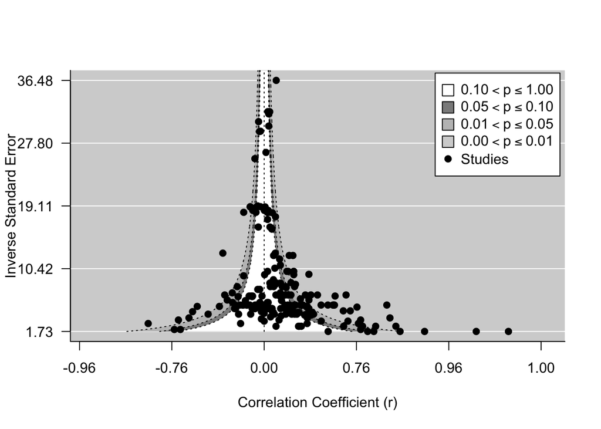

Figure 1: Funnel plot depicting the correlation between metabolism and fitness as a function of precision (1 / SE). The dotted lines are the theoretical 95% sampling variance intervals - the interval with which we expect effect size estimates to fall within if only sampling variance drives differences in effects. Shaded regions represent the p-value of studies. The white region indicates studies where the p-value is between 0.1 and 1; dark gray where the p-value of studies is between 0.05 and 0.1 and the lighter gray regions where the p-value of studies is significant.

```r
# Lets make a funnel plot to visualize the data in relation to the precision,
# inverse sampling standard error,
metafor::funnel(x = arnold_data_endo$Zr, vi = arnold_data_endo$Zr_v, yaxis = "seinv",
    digits = 2, level = c(0.1, 0.05, 0.01), shade = c("white", "gray55", "gray 75"),
    las = 1, xlab = "Correlation Coefficient (r)", atransf = tanh, legend = TRUE)
```

Here, we are setting a number of arguments. For greater detail you can look at the help file (`?funnel`), but we’ll explain a bit here:

1. `x` is the vector of effect sizes, Zr, you want plotted
2. `vi` is the vector of sampling variance estimates for each effect size, Zr_v
3. `yaxis` sets the type of sampling variance you want plotted `seinv` is the precision, or the inverse of the sampling standard error. Remember, to get from the sampling variance to the sampling standard error we just sqrt(Zr_v).
4. The `level` argument will plot contours, making this plot what we call a `contour enhanced funnel plot`. The contours relate to the level of statistical significance for each effect. See the legend.
5. `atransf` will transform Zr back to the correlation coefficient.

We can see from Fig. 1 above the typical funnel shape. You will notice that most effects lie in the positive correlation space – in other words there is a positive correlation between BMR and fitness. However, we also find some studies that show the opposite pattern. We expect that based on sampling theory alone, and indeed many of these effects fall close to the dotted sampling error intervals. Studies in the light grey regions are studies where the p-value was significant.

You can also make funnel plots using `ggplot`. Don’t worry about making a contour-enhanced version, just try making a simple funnel plot in the code chunk below. Remember to label your axes nicely. You can do that with the `labs()` function in `ggplot`.

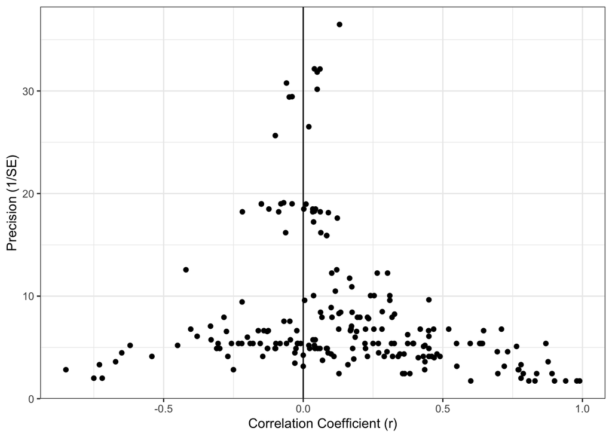

Figure 2: Funnel plot showing the precision of effects against their correlation

```r
ggplot(arnold_data_endo, aes(y = 1/sqrt(Zr_v), x = tanh(Zr))) + geom_point() + geom_vline(aes(xintercept = 0)) +
    labs(y = "Precision (1/SE)", x = "Correlation Coefficient (r)") + theme_bw()
```

#### **Question 1: What do we expect to see in the funnel plot if publication bias were present?**

> **In the literature we predict a positive correlation between metabolic rate and fitness. Think about what you would expect the funnel plot to look like, and why, if a ‘file-drawer’ bias existed.**

##### Your answer!

> We might expect under a file-drawer situation (i.e., where researchers stash away poorer quality studies showing opposite effects in their desk drawers) that studies with low power (i.e., low precision, wide standard errors, and small sample sizes) and non-significant correlations will go unpublished. This should be particularly true for studies that show the opposite to what we might predict by theory – specifically, negative correlations from studies with small sample sizes / low precision that are not significant. This is one factor that can drive what we call funnel asymmetry, showing a bunch of missing effect sizes in the bottom left corner of the funnel. “ADD YOUR ANSWER HERE”

##### Interpret the Funnel Plot

> If we look at Fig. 1 we do see some hint of this scenario. There is a noticeable blank space in the bottom left corner with negative correlations based on very small sample sizes that are generally small to moderate in magnitude going unpublished. The contour-enhanced funnel plot also tells us that these are studies that failed to find a significant correlation. But, interestingly, we also see that if the magnitude of correlation is large enough in the negative direction even with small sample sizes these can get published, but for the most part these are significant at 0.05. We can only speculate as to why or if this is even a real signature of publication bias. However, this might suggest that if folks estimate large enough correlations and these are in the opposite direction to what one might expect these arguably ‘surprising’ results are more likely to be published than if the correlation is weak and in the opposite direction. “ADD YOUR ANSWER HERE”

## **Task 3: Fitting a Multilevel Meta-Regression model to Test and Correct for Publication bias**

So far, the funnel plot has only been a visual tool to determine whether there is a possibility of publication bias existing. While useful, it does have a lot of limitations. We can, however, more formally quantify (i.e., statistically) if publication bias exists. We can also use meta-regression approaches to try and get a handle on how our meta-analytic mean effect size might change if there were no biases.

We can do that by recognizing that the sampling error is expected to co-vary with the magnitude and direction of effect size. In other words, we are making the prediction that, if we fit a meta-regression model that uses sampling variance as a fixed effect / moderator, we expect there to be a significant slope coefficient. That’s because there is an unequal distribution of effect sizes on either side of the funnel plot and the mean effect size when the sampling variance is high gets shifted resulting in the slope being different from 0.

To better understand this, lets think about flipping around the funnel plot, but this time lets use the sampling variance, not precision:

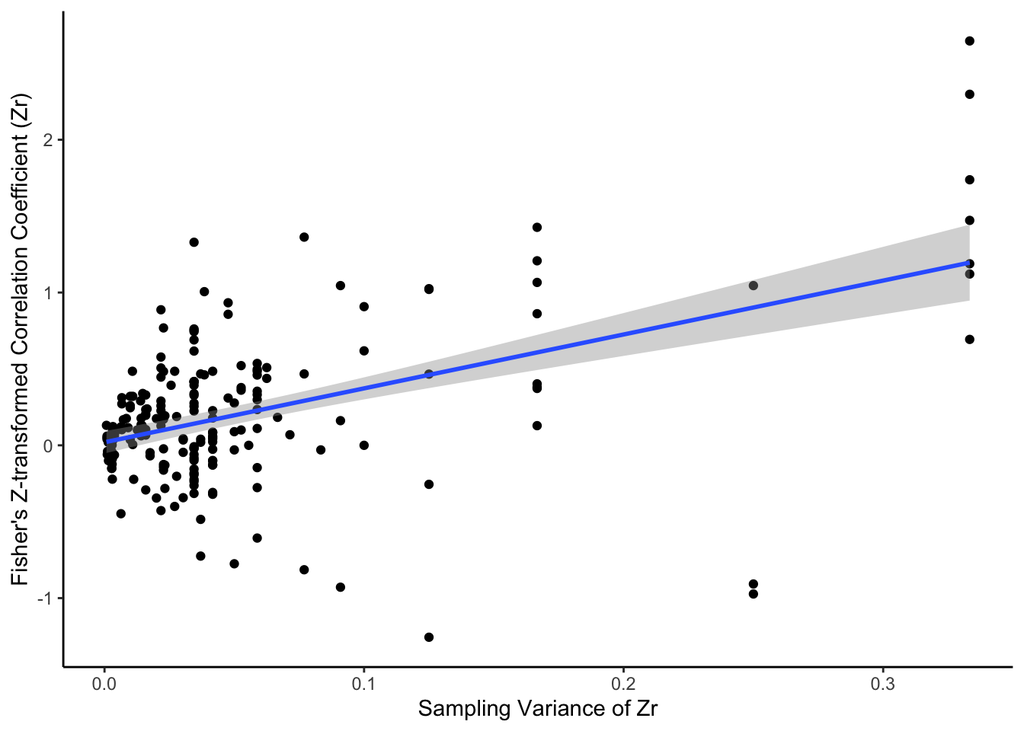

Figure 3: Plot of Fisher’s Zr against sampling variance for Zr. A linear model was fit to the data.

```r
ggplot(arnold_data_endo, aes(y = Zr, x = Zr_v)) + geom_point() + geom_smooth(method = lm) +
    labs(y = "Fisher's Z-transformed Correlation Coefficient (Zr)", x = "Sampling Variance of Zr") +
    theme_classic()
```

We can see from Figure 3 that this is essentially our funnel plot flipped around. We did this because we now are trying to predict variation in Zr as a function of sampling variance. We can see from the linear model fit that there appears to be a clear positive slope where the mean effect size is dragged ‘up’ when the sampling variance is large. This is what you would expect with publication bias because there are few effects in the opposite direction, the direction **not** predicted by our hypothesis when sample sizes are small, and therefore sampling variance is large. The idea here is that these studies are hard to publish or authors are just less likely to believe them, and therefore not publish them.

However, high heterogeneity / variability in effects could cause this relationship. So to could sources of non-independence or other moderators. Nakagawa et al. (2022) suggests fitting a multilevel meta-regression model with sampling variance along with other moderators or random effects to account for as many drivers of effect size heterogeneity as possible when testing if the slope is significant or not.

Let’s now apply the method proposed above to Arnold et al. (2021)’s data. To simplify, we are just going to remove other moderators and only fit Zr_V. This just simplifies the interpretation of the intercept, but we could always include other moderators in this model as well. We will, however, control for a key source of non-independence, study id (called `Ref`), and we’ll explicitly estimate a within study variance (`residual`) as well.

```r
# Including sampling variance as moderator
metareg_v <- rma.mv(Zr ~ Zr_v, V = Zr_v, random = list(~1 | Ref, ~1 | residual),
    test = "t", dfs = "contain", data = arnold_data_endo)
summary(metareg_v)
```

```
##
## Multivariate Meta-Analysis Model (k = 209; method: REML)
##
##   logLik  Deviance       AIC       BIC      AICc
## -76.1349  152.2698  160.2698  173.6006  160.4678
##
## Variance Components:
##
##             estim    sqrt  nlvls  fixed    factor
## sigma^2.1  0.0559  0.2364     62     no       Ref
## sigma^2.2  0.0381  0.1953    209     no  residual
##
## Test for Residual Heterogeneity:
## QE(df = 207) = 840.6907, p-val < .0001
##
## Test of Moderators (coefficient 2):
## F(df1 = 1, df2 = 207) = 18.7982, p-val < .0001
##
## Model Results:
##
##          estimate      se    tval   df    pval    ci.lb   ci.ub
## intrcpt    0.0469  0.0467  1.0028   60  0.3200  -0.0466  0.1403
## Zr_v       3.0051  0.6931  4.3357  207  <.0001   1.6387  4.3716  ***
##
## ---
## Signif. codes:  0 '***' 0.001 '**' 0.01 '*' 0.05 '.' 0.1 ' ' 1
```

```r
# How much variation does this model explain in Zr?
r2 <- orchaRd::r2_ml(metareg_v)
r2
```

```
##    R2_marginal R2_conditional
##           0.31           0.72
```

We can see that sampling variance explains 31.32% of effect size variance. This is the marginal $R^2$, which tell us how much variation the ‘fixed effects’ or moderators explain in the model. Conditional $R^2$ tells us that the full model, that accounts for the both the fixed and random effects, explains 72.14% of variance in effect size.

#### **Question 2: Is there evidence for publication bias? If so, what is the adjusted meta-analytic mean estimate?**

> **Note**: Write out your answer using in-line code chunks that extract the relevant values from the model object.

##### Your Answer!

> Yes, there is evidence for publication bias because the slope estimate for `Zr_V` is significant. We can see from this model that the adjusted `Zr` when there is *no* uncertainty (i.e., the intercept) is 0.05with a 95% confidence interval that overlaps zero (i.e., 95% CI = -0.05 to 0.14). In other words, if no uncertainty around estimates exists, or we have a very high powered set of studies than we would expect the correlation to be, on average, 0.05. “ADD YOUR ANSWER HERE”

## **Task 4: Visual inspections of possible publication bias – time-lag bias**

Time-lag bias is a very common form of publication bias that results from a change in the average effect size with the accumulation of new studies. Often, under-powered studies that find surprising results are published first, and these initial studies usually stimulate a swath of new experiments seeking to test whether such a pattern exists in a new study system. To some extent, this is a good thing, and is expected. We need studies to replicate the finding so we are not fooled by the result.

We know though that small studies are susceptible to huge sampling error. This can result in over-inflated effect sizes. As more studies accumulate, the average effect size usually converges on the ‘true’ mean.

Time-lag bias is usually depicted in two ways. First, using what is called a ‘cumulative meta-analysis’. This is where we conduct a meta-analysis on a subset of data adding to this data as we move through time. We usually visualise this using what is called a ‘cumulative forest plot’.

Second, we can also test whether the mean effect size changes with the year of publication using visual and meta-regression approaches.

Given the two methods are similar, we’ll focus on the second option to keep things simple.

Let’s first focus on some visuals in this task. Let’s visualize whether we see any relationship between *average effect size* and the *year of publication*? Use `ggplot` to do this. Scale the size of the points based on their sampling error. Remember to clearly label the axes and the legend.

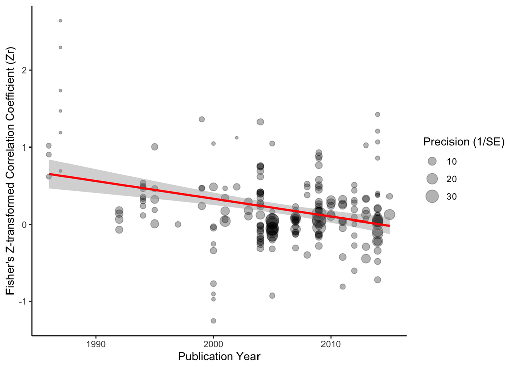

Figure 4: Plot of Zr as a function of publication year. Points are scaled in relation to their precision (1/sqrt(Zr_v)). Small points indicate effects with low precision or high sampling varaince

```r
ggplot(arnold_data_endo, aes(y = Zr, x = Year, size = 1/sqrt(Zr_v))) + geom_point(alpha = 0.3) +
    geom_smooth(method = lm, col = "red", show.legend = FALSE) + labs(x = "Publication Year",
    y = "Fisher's Z-transformed Correlation Coefficient (Zr)", size = "Precision (1/SE)") +
    theme_classic()
```

Would you look at that!

#### **Question 3: There are a few key things to takeaway from Figure 4 which seem to support our suspicions about time-lag bias being present in these data. Describe three important features that stand out.**

##### Your Answer!

1. There does appear to be a clear negative relationship with year.
2. Also of note are that the earlier year studies have much higher sampling variance (i.e., lower precision), just like we might expect.
3. These early studies appear to have a far higher (exaggerated) effect size compared with studies that are done in later years. “ADD YOUR ANSWER HERE”

## **Task 5: Quantifying time lag bias using multilevel meta-regression**

```r
# Including sampling variance as moderator
metareg_time <- rma.mv(Zr ~ Year, V = Zr_v, random = list(~1 | Ref, ~1 | residual),
    test = "t", dfs = "contain", data = arnold_data_endo)
summary(metareg_time)
```

```
##
## Multivariate Meta-Analysis Model (k = 209; method: REML)
##
##   logLik  Deviance       AIC       BIC      AICc
## -79.7779  159.5557  167.5557  180.8866  167.7537
##
## Variance Components:
##
##             estim    sqrt  nlvls  fixed    factor
## sigma^2.1  0.0725  0.2693     62     no       Ref
## sigma^2.2  0.0370  0.1923    209     no  residual
##
## Test for Residual Heterogeneity:
## QE(df = 207) = 935.0576, p-val < .0001
##
## Test of Moderators (coefficient 2):
## F(df1 = 1, df2 = 60) = 9.8414, p-val = 0.0026
##
## Model Results:
##
##          estimate       se     tval  df    pval    ci.lb    ci.ub
## intrcpt   38.1671  12.1138   3.1507  60  0.0025  13.9358  62.3983  **
## Year      -0.0189   0.0060  -3.1371  60  0.0026  -0.0310  -0.0069  **
##
## ---
## Signif. codes:  0 '***' 0.001 '**' 0.01 '*' 0.05 '.' 0.1 ' ' 1
```

```r
# How much variation does time when results were published explain in Zr?
r2_time <- orchaRd::r2_ml(metareg_time)  #'ADD YOUR CODE HERE'
r2_time
```

```
##    R2_marginal R2_conditional
##           0.14           0.71
```

#### **Question 4: How much variation in Zr among studies is driven by changes through time?**

> **Note**: Write out your answer using in-line code chunks that extract the relevant values from the model object.

##### Your Answer!

> Time-lag explains 13.83% of the variation in Zr. “ADD YOUR ANSWER HERE”

It’s clear that we have evidence of a time-lag bias. The mean effect size is predicted to decrease as more studies accumulate! But, wait, we also have evidence for other possible publication biases, such as ‘file-drawer’ effects. We can actually create a model that accounts for **both** of these effects, and that accounts for the possible covariance between the two (i.e., sampling variance is expected to be high in early years). Let’s fit that model.

```r
# Including sampling variance and year as moderators to account for both!
metareg_time <- rma.mv(Zr ~ Year + Zr_v, V = Zr_v, random = list(~1 | Ref, ~1 | residual),
    test = "t", dfs = "contain", data = arnold_data_endo)
summary(metareg_time)
```

```
##
## Multivariate Meta-Analysis Model (k = 209; method: REML)
##
##   logLik  Deviance       AIC       BIC      AICc
## -73.4782  146.9564  156.9564  173.5957  157.2564
##
## Variance Components:
##
##             estim    sqrt  nlvls  fixed    factor
## sigma^2.1  0.0513  0.2266     62     no       Ref
## sigma^2.2  0.0377  0.1942    209     no  residual
##
## Test for Residual Heterogeneity:
## QE(df = 206) = 833.3231, p-val < .0001
##
## Test of Moderators (coefficients 2:3):
## F(df1 = 2, df2 = 59) = 12.2763, p-val < .0001
##
## Model Results:
##
##          estimate       se     tval   df    pval    ci.lb    ci.ub
## intrcpt   25.0498  11.3651   2.2041   59  0.0314   2.3082  47.7914    *
## Year      -0.0125   0.0057  -2.2000   59  0.0317  -0.0238  -0.0011    *
## Zr_v       2.5542   0.7116   3.5894  206  0.0004   1.1513   3.9571  ***
##
## ---
## Signif. codes:  0 '***' 0.001 '**' 0.01 '*' 0.05 '.' 0.1 ' ' 1
```

```r
# How much variation does time when results were published explain in Zr?
r2_time_sv <- orchaRd::r2_ml(metareg_time)  #'ADD YOUR CODE HERE'
r2_time_sv
```

```
##    R2_marginal R2_conditional
##           0.36           0.73
```

Great! That was easy. Just like any old linear mixed effect model we can just add moderators / fixed effects to the formula. Here, we can see that there is clear evidence, even when accounting for the covariance between the two, for both file-drawer and time-lag biases in these data.

But wait, the intercept in this model is really different from `metareg_v`. Why? Well, this is expected because the interpretation of the intercept is the mean effect size when `Year` **and** sampling variance = 0! That’s just weird right? What does a Year of 0 really mean?

It turns out that we can `trick` the model into estimating an intercept – the overall meta-analytic mean – that is more relevant and more easily interpreted for us. To do that, we can ‘centre’ the `Year` variable. Remember back to *workshop 8 on Statistical Models* where we subtracted the mouse mass from the cage mean? Yep, it’s the same thing, we just don’t square it.

What does centering do for us here? Well, for simplicity, we can centre on the mean of the `Year` column by simply subtracting every value of `Year` by the “mean year”. This changes the variable so that 0 is now the mean Year in the data set. Why don’t you do that in the code block below. Create a new column called `Year_c`. Use the `tidyverse` :

```r
arnold_data_endo <- arnold_data_endo %>%
    mutate(Year_c = Year - mean(Year))  # 'ADD YOUR CODE HERE'
```

Great, now we have added our ‘centered on the mean’ Year and called this new variable `Year_c`. We can now refit the model using `Year_c` instead of year. Do that in the code chunk below:

```r
# Including sampling variance and mean centered year as moderators to account
# for both!
metareg_time_c <- rma.mv(Zr ~ Year_c + Zr_v, V = Zr_v, random = list(~1 | Ref, ~1 |
    residual), test = "t", dfs = "contain", data = arnold_data_endo)
summary(metareg_time_c)  # 'ADD YOUR CODE HERE'
```

```
##
## Multivariate Meta-Analysis Model (k = 209; method: REML)
##
##   logLik  Deviance       AIC       BIC      AICc
## -73.4782  146.9564  156.9564  173.5957  157.2564
##
## Variance Components:
##
##             estim    sqrt  nlvls  fixed    factor
## sigma^2.1  0.0513  0.2266     62     no       Ref
## sigma^2.2  0.0377  0.1942    209     no  residual
##
## Test for Residual Heterogeneity:
## QE(df = 206) = 833.3231, p-val < .0001
##
## Test of Moderators (coefficients 2:3):
## F(df1 = 2, df2 = 59) = 12.2763, p-val < .0001
##
## Model Results:
##
##          estimate      se     tval   df    pval    ci.lb    ci.ub
## intrcpt    0.0697  0.0467   1.4943   59  0.1404  -0.0236   0.1631
## Year_c    -0.0125  0.0057  -2.2000   59  0.0317  -0.0238  -0.0011    *
## Zr_v       2.5542  0.7116   3.5894  206  0.0004   1.1513   3.9571  ***
##
## ---
## Signif. codes:  0 '***' 0.001 '**' 0.01 '*' 0.05 '.' 0.1 ' ' 1
```

What happened? The model has changed, and in particular the `intrcpt`. Why? Well, have a think about the meaning of the `intrcpt`. It is the mean when `Year_c` and `Zr_v` are both set to 0. But, remember now that a value of `Year_c` that is 0 actually means an ‘average Year’ (we could of course have centered it on other years…maybe 2022?). This changes the interpretation of the `intrcpt`! That explains why the value of `intrcpt` is different.

What’s really cool here is that, now, we have been able to deal with both types of publication bias in a single model and re-estimate (i.e., predict) what the mean Zr value is when sampling variance is 0 and for an average year in the dataset, which we hope will be around the point when the average effect size begins to converge on the true mean.

#### **Question 5: What is the average correlation between metabolism and fitness now predicted to be when we account for both sources of publication bias?**

> **Note**: Write out your answer using in-line code chunks that extract the relevant values from the model object.

##### Your Answer!

> The overall mean correlation (r) when small sample and time-lag biases are controlled for is 0.07. “ADD YOUR ANSWER HERE”

## **Rendering**

> Now that you have completed the Rmarkdown document try rendering it as an HTML. Does it work? If not, why not? Remember that you were giving a ref.bib file. Make sure you have this file in your working directory. Also check that the yaml header (right at the top of the RMarkdown) has the correct path. If it’s working one code chunk at a time try to clear your working directory (i.e., `rm(list = ls()`) and re-run each code chunk.

## **References**

Arnold, Pieter A., Steven Delean, Phillip Cassey, and Craig R. White. 2021. “Meta‐analysis Reveals That Resting Metabolic Rate Is Not Consistently Related to Fitness and Performance in Animals.” *Journal of Comparative Physiology B* 191: 1097–1110.

Jennions, M. D., C. J. Lortie, M. S. Rosenberg, and H. R. Rothstein. 2013. “Publication and Related Biases.” *In: Handbook of Meta-Analysis in Ecology and Evolution (Eds J. Koricheva, J. Gurevitch & K. Mengersen). Princeton University Press, Princeton and Oxford.*, pp 207–236.

Nakagawa, Shinichi, Malgorzata Lagisz, Michael D Jennions, Julia Koricheva, Timothy H Parker Daniel W. A. Noble, Alfredo Sánchez-Tójar, Yefeng Yang, and Rose E O’Dea. 2022. “Methods for Testing Publication Bias in Ecological and Evolutionary Meta-Analyses.” *Methods in Ecology and Evolution* 13 (1): 4–21.

O’Dea, Rose E., Malgorzata Lagisz, Michael D. Jennions, Julia Koricheva, Daniel W. A. Noble, Timothy H. Parker, Jessica Gurevitch, et al. 2021. “Preferred Reporting Items for Systematic Reviews and Meta-Analyses in Ecology and Evolutionary Biology: A PRISMA Extension.” *Biological Reviews* doi: 10.1111/brv.12721.

Rothstein, H. R., A. J. Sutton, and M. Borenstein. 2005. “Publication Bias in Meta-Analysis: Prevention, Assessment and Adjustments.” *Wiley, Chichester*.